# Biases and Ability Splits, Thirty Years Later

Do some hitters handle falling behind in the count better than others? Statcast gives a new answer to an old question.

Statcast

Bayesian

situational effects

Author

Jim Albert

Published

October 21, 2026

## How this post came about

This post is a bit of an experiment. The analysis behind it, and a first draft of the post itself, were done in a few days of conversation with Claude, Anthropic’s AI assistant, working directly with my Statcast files.

I supplied the questions and the direction. Claude wrote the R, Stan and Quarto code, ran the models, and reported back. The work went roughly like this:

- I started by asking Claude to extend the situational random effects model from my [Bayesian workflow paper](https://bayesball.github.io/papers/bayes_workflow.html) so that each hitter could have his own count effect.
- When the fit to expected wOBA turned up a puzzling result for 2026, Claude ran the same checks on five earlier seasons and on other measures of contact. Those checks pointed to exit velocity as the place where hitters really differ.
- I suggested looking at bat speed and swing length together. Claude built a model that treats each hitter’s swing changes as noisy measurements.
- Finally, I gave Claude my 1994 paper and asked it to relate the new results to the old ones. That comparison is the frame for this post.

I checked the work along the way, and so did Claude. At one point it corrected one of its own early results: a strong-looking correlation that turned out to come from sharing measurement noise between two variables. When a figure in an earlier draft didn’t seem to match the text, it recomputed the numbers independently before fixing the figure. The questions and the judgments about what matters are mine. Much of the heavy lifting was not.

## An old question

Back in 1994 I published a paper in the *Journal of the American Statistical Association* called “Exploring Baseball Hitting Data: What About Those Breakdown Statistics?” At the time, STATS Inc. had just started publishing detailed situational splits for every hitter: home and away, day and night, grass and turf, against lefties and righties, ahead and behind in the count, and so on. Broadcasters loved them. If a hitter struck out, it was because he was behind in the count against a left-hander on turf.

I looked at the 1992 batting averages of 154 regulars across eight of these situations, using a Bayesian model that let each player’s situational effect be estimated while borrowing strength from all the other players. The main conclusions were sobering:

- **Most situations don’t matter much.** Grass versus turf, day versus night, runners in scoring position and before versus after the All-Star break were essentially noise. Home field and the platoon advantage were real but small.
- **The count is the exception.** Hitters batted about 120 points higher when ahead in the count than with two strikes.
- **Individual splits are very hard to see.** A player’s split in one season told you little about his true ability in that situation. The few players with eye-catching splits in 1992 usually had splits in the *opposite* direction over the previous four years.

Bill James gave me a useful way to think about this. Some situational effects are **biases**: they affect every hitter about the same way. A hitter’s ability doesn’t change because he is playing on grass or in daylight. Others are **ability splits**, where hitters genuinely differ. James thought the count might be an ability split, since hitting with two strikes is tied to a hitter’s tendency to strike out. My data were consistent with that, but the signal was weak. Only one player, Tony Gwynn, showed a clearly unusual count split year after year: he hit about the same no matter the count.

## What’s different now

In 1992 all I had for each at-bat was hit or out. Statcast now measures every ball in play: how hard it was hit, at what angle, and its expected value. Since 2024 it has also measured the swing itself, including bat speed and swing length. So I revisited the count question with the 2025 and 2026 seasons.

The comparison is simple: for each hitter, how does his contact when he is **behind** in the count (0-1, 0-2, 1-2, 2-2) compare with his contact in **neutral** counts (0-0, 1-0, 1-1, 2-1, 3-2)? The model is a direct descendant of the 1994 one. Each hitter has an overall level and his own count effect, and the count effects come from a common distribution, so a hitter’s estimate is pulled toward the average by an amount that depends on how much data he has. The new wrinkle is that the model also estimates whether a hitter’s count effect is related to how good he is.

## Finding 1: For quality of contact, the count is a bias

I first measured contact quality with expected wOBA on balls in play, which rates each batted ball by its exit velocity and launch angle. Hitters make weaker contact when behind, as you’d expect. But once you account for sampling noise, there is essentially **no evidence that hitters differ** in how much worse their contact gets. The count effect looks the same for everyone, a bias in James’s sense. A model that lets each hitter have his own effect predicts the second half of the season no better than a model with one effect for all.

That squares with 1994 in an interesting way. Expected wOBA on balls in play leaves out strikeouts entirely. If the count’s ability split in batting average ran through strikeout tendency, as James suggested, then removing strikeouts should remove the split. That is what happens.

## Finding 2: For exit velocity, the count is an ability split

Exit velocity is a different story. In 2026 the average hitter hit the ball about **1.2 mph softer** when behind (1.6 mph in 2025). The true count effect also varies from hitter to hitter, with a standard deviation of about **1.1 mph**, nearly as large as the average effect itself. This time a model with one effect for every hitter fails a basic check: it can’t reproduce how spread out the hitters’ observed differences are.

The differences also line up with power. Hitters who hit the ball hardest overall tend to lose the most exit velocity when they fall behind:

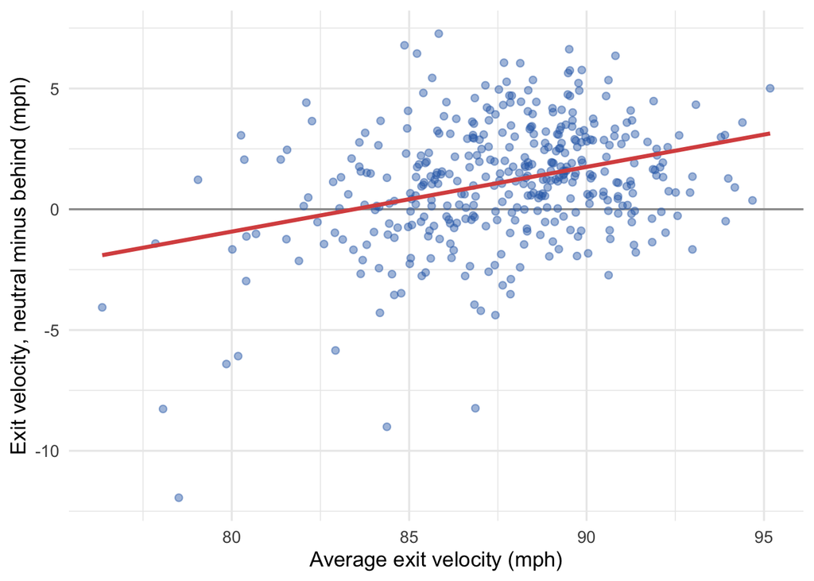

Figure 1: Each point is a 2026 hitter with at least 100 balls in play. Harder hitters tend to lose more exit velocity when behind in the count.

```r
ev |>
  filter(season == 2026) |>
  ggplot(aes(level, gap)) +
  geom_hline(yintercept = 0, colour = "grey60") +
  geom_point(alpha = 0.45, colour = blue) +
  geom_smooth(method = "lm", se = FALSE, colour = red) +
  labs(x = "Average exit velocity (mph)",
       y = "Exit velocity, neutral minus behind (mph)")
```

So Tony Gwynn’s pattern turns out to be general. The hitters with the smallest count effects in both 2025 and 2026 are contact and speed players: Steven Kwan, TJ Friedl, Myles Straw, Chandler Simpson, Nick Allen, Kyle Isbel and Victor Scott. They put the ball in play about as firmly behind in the count as in neutral counts. At the other end are sluggers such as Shohei Ohtani, James Wood, Elly De La Cruz and Francisco Lindor, who were among the largest in both seasons.

## Finding 3: It’s about effort, not length

Why would some hitters lose more exit velocity than others? The usual explanation is that hitters “shorten up” with two strikes: they choke up, cut down the swing and just try to put the ball in play. Since 2024 Statcast has measured every swing’s **bat speed** (at the moment of contact or near miss) and **swing length** (the distance the bat head travels), so we can check.

### Two ways to slow a bat down

A hitter can lose bat speed in two different ways:

- **A shorter swing.** A shorter path gives the bat less distance to accelerate. Within each hitter’s own swings, every extra inch of swing length goes with about 0.18 mph more bat speed.
- **A less aggressive swing.** He can swing the same length but less hard.

The figure below shows both measures, count by count, across all 2026 swings.

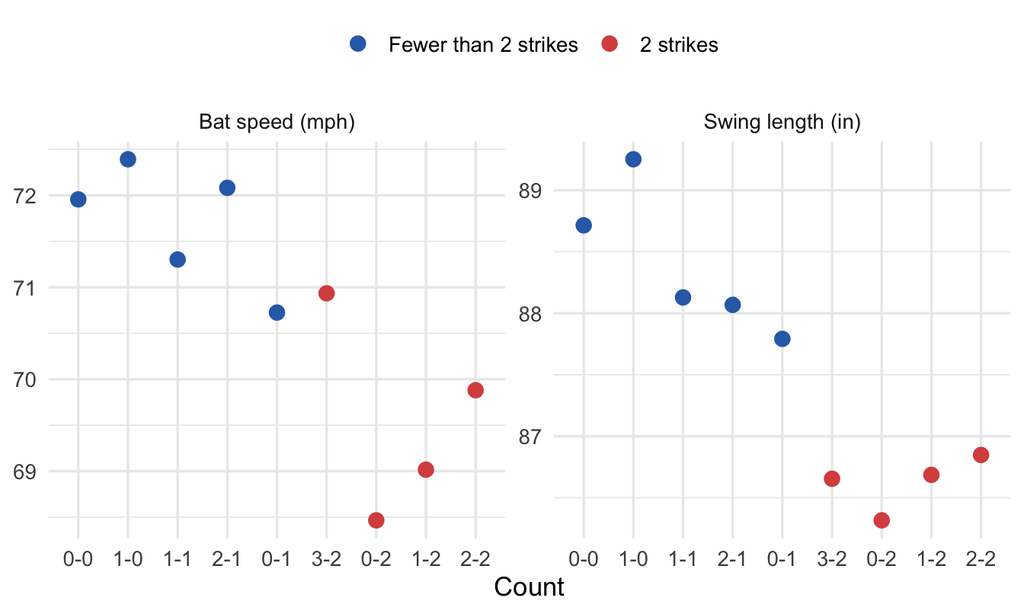

Figure 2: Average bat speed and swing length by count, 2026 (swings that didn’t put the ball in play). Red: two-strike counts. Every two-strike count has a shorter swing, but at 3-2 hitters keep most of their bat speed.

```r
by_count |>
  pivot_longer(c(`Bat speed (mph)`, `Swing length (in)`)) |>
  ggplot(aes(cnt, value, colour = strikes2)) +
  geom_point(size = 3) +
  facet_wrap(~ name, scales = "free_y") +
  scale_colour_manual(values = c(`FALSE` = blue, `TRUE` = red),
                      labels = c("Fewer than 2 strikes", "2 strikes"), name = NULL) +
  labs(x = "Count", y = NULL) +
  theme(legend.position = "top")
```

With two strikes, swings get both shorter and slower. From 0-0 to 0-2 the average swing loses about 2.4 inches and 3.5 mph. But the full count shows the two can be separated. At 3-2, swings are about as short as in the other two-strike counts (86.7 in), yet bat speed stays near its 0-0 level (70.9 mph versus 72.0). Protecting the plate with a full count, hitters cut the swing down but still swing hard.

### Hitters mostly ease off

Splitting each hitter’s drop in bat speed into those two parts gives a clear answer. Behind in the count (versus neutral), the average hitter’s bat speed drops about 2.0 mph. His swing is only about 1.2 in shorter, which accounts for just 0.2 mph. The other 1.8 mph is bat speed given up *at the same swing length*. In other words, hitters mostly ease off rather than shorten up.

And it’s the easing off that costs exit velocity. The next figure groups hitters into thirds by each kind of change and shows how much more (or less) exit velocity they lose when behind than their power would predict:

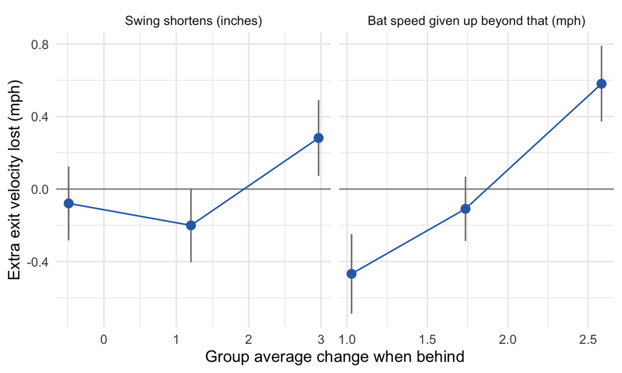

Figure 3: 2026 hitters grouped into thirds by how much their swings shorten (left) and by how much bat speed they give up beyond what the shorter swing explains (right). The vertical axis is each group’s average exit-velocity loss when behind, relative to what the hitter’s overall power predicts (±1 standard error).

```r
bind_rows(
  drops |> mutate(third = ntile(len, 3), x = len,
                  panel = "Swing shortens (inches)"),
  drops |> mutate(third = ntile(effort, 3), x = effort,
                  panel = "Bat speed given up beyond that (mph)")) |>
  group_by(panel, third) |>
  summarise(x = mean(x), se = sd(gap_adj) / sqrt(n()), y = mean(gap_adj),
            .groups = "drop") |>
  mutate(panel = factor(panel, levels = c("Swing shortens (inches)",
                                          "Bat speed given up beyond that (mph)"))) |>
  ggplot(aes(x, y)) +
  geom_hline(yintercept = 0, colour = "grey60") +
  geom_errorbar(aes(ymin = y - se, ymax = y + se), width = 0, colour = "grey50") +
  geom_line(colour = blue) +
  geom_point(size = 3, colour = blue) +
  facet_wrap(~ panel, scales = "free_x") +
  labs(x = "Group average change when behind",
       y = "Extra exit velocity lost (mph)")
```

The right panel shows a steady pattern. The third of hitters who ease off most lose about a mph more exit velocity than the third who ease off least, after accounting for power. The left panel is weaker and uneven. What pattern there is comes mostly from overlap: hitters whose swings shorten the most also tend to ease off more. The model below separates the two.

### What the model says

These raw comparisons understate the relationship, because one season of swings measures each hitter’s tendencies with a lot of noise. (Splitting a hitter’s swings in half, the two halves agree only moderately.) The full Bayesian model treats each hitter’s swing changes as noisy measurements of his true tendencies, alongside his power and his count effect. It finds:

- **Easing off costs exit velocity.** Comparing hitters of similar power, each mph of bat speed given up beyond what the shorter swing costs adds about **1.35 mph** to a hitter’s exit-velocity loss (90% interval 0.8 to 1.9).
- **Shortening up costs nothing extra.** Once easing off is accounted for, how much shorter the swing gets adds essentially nothing.
- **Together they explain a lot.** A hitter’s power alone explains about a third of the variation in true count effects. Power plus the two swing changes explain about **two-thirds**.

The 1.35 figure is reassuring for another reason: it is close to what physics predicts. Alan Nathan’s work on the bat–ball collision gives a simple rule of thumb for well-struck balls. Exit velocity is roughly 0.2 times the pitch speed plus 1.2 times the bat speed, so each mph of bat speed is worth about 1.2 mph of exit velocity. A purely statistical model, which knows nothing about collisions, lands in the same neighborhood.

One more wrinkle: the power hitters who lose the most exit velocity are *not* the ones who ease off most. Harder hitters actually give up slightly less bat speed when behind. Power and easing off are two separate reasons a hitter loses exit velocity when behind, and each matters on its own.

## Finding 4: This time the splits hold up, a little

The most discouraging result in 1994 was that unusual splits didn’t repeat. So the key test here is whether a hitter’s exit-velocity gap in one season tells you anything about his gap the next season.

To check, I took the 292 hitters with at least 100 balls in play in both seasons and split them into three equal groups by their 2025 gap, the drop in exit velocity from neutral counts to behind:

- **Small 2025 gaps.** These hitters averaged -0.9 mph, which means they actually hit the ball a bit *harder* when behind.
- **Middle 2025 gaps.** These averaged 1.7 mph.
- **Large 2025 gaps.** These averaged 4.0 mph.

Then I asked what the same three groups did in 2026. Before looking, it helps to know what the two extreme answers would look like:

- **If the 2025 gaps were pure luck,** all three groups would come back to the 2026 league average of about 1.2 mph. The points would lie on the flat dashed line in the figure.
- **If the 2025 gaps were pure skill,** each group would repeat its 2025 gap. The points would lie on the diagonal dotted line.

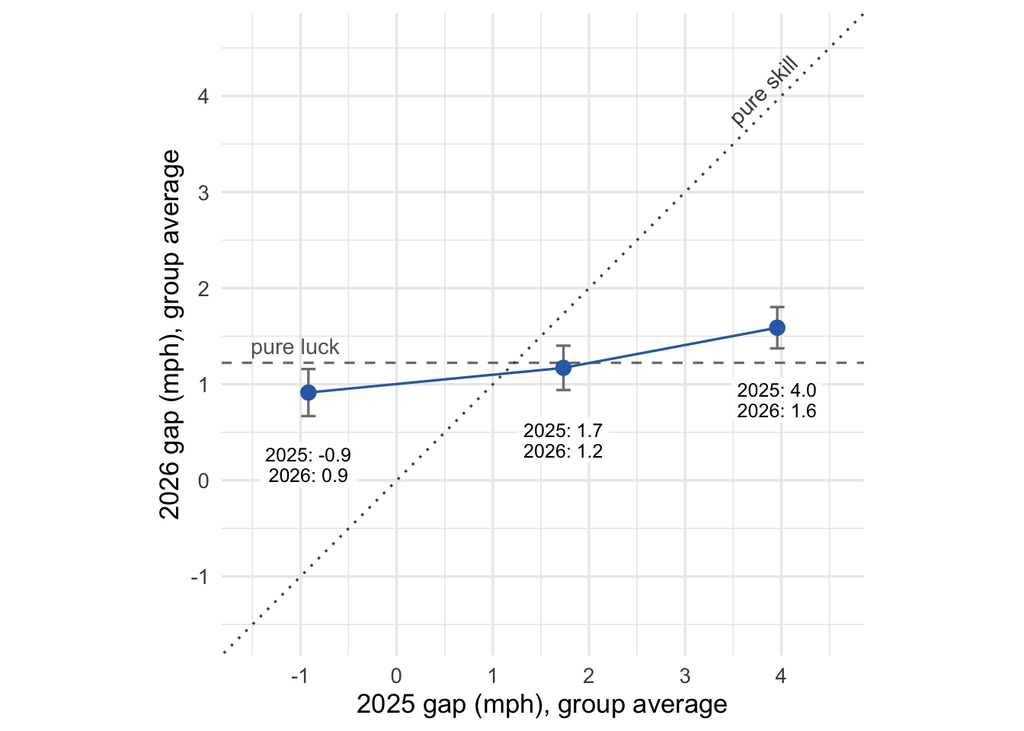

Figure 4: Hitters split into thirds by their 2025 exit-velocity gap (neutral minus behind). Each blue point shows a group’s average 2025 gap (horizontal position) and its average 2026 gap (vertical position); the grey bars are ±1 standard error of the 2026 average. Flat dashed line: what pure luck would give. Dotted diagonal: what pure skill would give.

```r
lims <- range(c(thirds$x, thirds$y, avg26)) + c(-0.6, 0.6)
ggplot(thirds, aes(x, y)) +
  geom_hline(yintercept = avg26, linetype = 2, colour = "grey50") +
  geom_abline(slope = 1, intercept = 0, linetype = 3, colour = "grey30") +
  annotate("text", x = lims[1], y = avg26, label = "pure luck",
           hjust = 0, vjust = -0.6, colour = "grey40", size = 3.8) +
  annotate("text", x = lims[2] - 0.3, y = lims[2] - 0.3, label = "pure skill",
           hjust = 1, vjust = -0.6, angle = 45, colour = "grey30", size = 3.8) +
  geom_errorbar(aes(ymin = y - se, ymax = y + se), width = 0.15, colour = "grey50") +
  geom_line(colour = blue) +
  geom_point(size = 3, colour = blue) +
  geom_label(aes(label = sprintf("2025: %.1f\n2026: %.1f", x, y)),
             nudge_y = -0.75, size = 3.3, label.size = 0, fill = "white",
             alpha = 0.85, lineheight = 0.9) +
  scale_x_continuous(breaks = seq(-3, 6, 1)) +
  scale_y_continuous(breaks = seq(-3, 6, 1)) +
  coord_equal(xlim = lims, ylim = lims) +
  labs(x = "2025 gap (mph), group average",
       y = "2026 gap (mph), group average")
```

The answer is in between, but much closer to luck. The three groups, which were 4.9 mph apart in 2025, ended up only 0.7 mph apart in 2026:

- The small-gap group went from -0.9 to 0.9 mph.
- The middle group went from 1.7 to 1.2 mph.
- The large-gap group went from 4.0 to 1.6 mph.

But the order held: the hitters with the largest gaps in 2025 still had the largest gaps in 2026, and the smallest still had the smallest.

A single number summarizes this. On average, each extra mph of gap in 2025 carried over as only about 0.17 mph in 2026. Loosely speaking, about 17% of a hitter’s one-season gap is something real about him that carries into the next season, and the other 83% is noise that disappears. (In correlation terms, the year-to-year correlation of the gaps is 0.17. For expected wOBA it is only 0.09.)

That is the same lesson as 1994, where a player’s four-year count split pulled his 1992 split about 68% of the way back toward the average: **a one-season split should be shrunk most of the way to the league average.** The difference is that now, after shrinking, something is left.

The Bayesian model does that shrinking for every hitter automatically, and its estimates show the persistence more clearly than the raw gaps do:

- **Large effects persisted.** The model was confident (probability above 0.9) that 21 hitters had unusually large count effects in 2026. Of these, 18 had above-average effects in 2025 too.
- **Small effects persisted.** It was equally confident that 21 hitters had unusually small effects. Of these, 19 were below average in 2025.
- **In 1994 they didn’t.** Seven of my nine outliers had effects in the opposite direction over the previous four years.

**The practical takeaway.** If you want to predict how much a hitter will lose when behind in the count next season, start with the league average and move only a small step toward his own number. That approach predicts next season’s gaps about 7% better than using the league average alone. Using his raw one-season gap does much worse than either. The skill is real, but a single season shows only a faint outline of it.

## What changed, and what didn’t

Thirty years on, the main lesson of the breakdown-statistics paper still holds: **most of what looks like a situational split in a single season is noise**, and a sensible estimate shrinks a hitter’s split heavily toward the league average. For contact quality as a whole, the count still looks like a bias.

What’s new is that richer data let us see *where* the ability split lives. It isn’t in how good a hitter’s contact is when he puts the ball in play behind in the count. It’s in how hard he hits it, which depends on how much he backs off his swing. Power hitters back off; contact hitters, like Gwynn before them, mostly don’t. Batting average could never have shown that. It took exit velocity and bat tracking.

*The full analysis, including the Stan models, posterior predictive checks and out-of-sample comparisons, is in a longer Quarto document. I’m happy to share it.*

**Reference.** Albert, J. (1994). Exploring baseball hitting data: What about those breakdown statistics? *Journal of the American Statistical Association*, 89(427), 1066–1074.